# tpagliar_1.rmd

Tim Pagliari tpagliar@kent.edu

9/20/2020

#### Below is Tim Pagliari (tpagliar@kent.edu)’s submission for Assignment 1 in MIS-64060-002-202080.

Data used is from the CScoreCard dataset, which is the Most Recent Institution Level Data from the Department of Education’s College Scorecard. Retrieved from: https://collegescorecard.ed.gov/data/; I’ve removed some of the later columns as the original file is greater than 100MB and I didn’t try to push it until i had completed the assignment.

The MaxDegree variable is categorical and references the highest degree level awarded by the institution.

```r
count_Rows <- nrow(CScoreCard) #First, I'll count the number of rows (or number of institutions present)
var_MaxDegree <- CScoreCard$HIGHDEG
count_BSplus <- sum(var_MaxDegree>=3) #Find those that award Baccalaureate Degrees or Higher
count_MSplus <- sum(var_MaxDegree>=4) #Find those that award Master's Degrees or Higher
```

There are **6806** schools in the dataset, using the MaxDegree information we know that **2725** schools award Bachelor’s degrees or higher, and **2004** schools award Master’s degrees or higher.

```r
sat<-as.numeric(CScoreCard$SAT_AVG, na.rm=TRUE)
var_maxsat <- max(sat,na.rm=TRUE) #is the maximum SAT average among schools who reported.
SchoolWMAXSAT <- CScoreCard[which.max(sat),4] #This score belongs to:
sqrt_sat <- sqrt(sat) #An example transformation of the SAT scores into the square root of the SAT scores
act_matmid<-as.numeric(CScoreCard$ACTMTMID,na.rm=TRUE)
```

Using this variable, we know that **1566** is the maximum SAT average among schools who reported this data, and that score belongs to **California Institute of Technology**. If we wanted to do a transformation on that score, the **sqrt_sat** is the square root of the SAT scores.

#### Plots of the SAT vs ACT midpoints and a histogram of the admit rate frequencies are below.

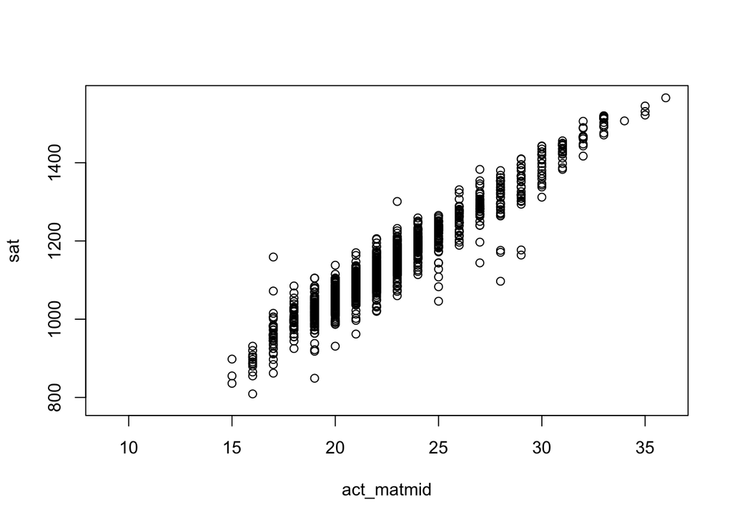

```r
plot(act_matmid,sat)#Here is a plot of the SAT scores (y axis) vs the midpoint ACT Math score (x axis)
```

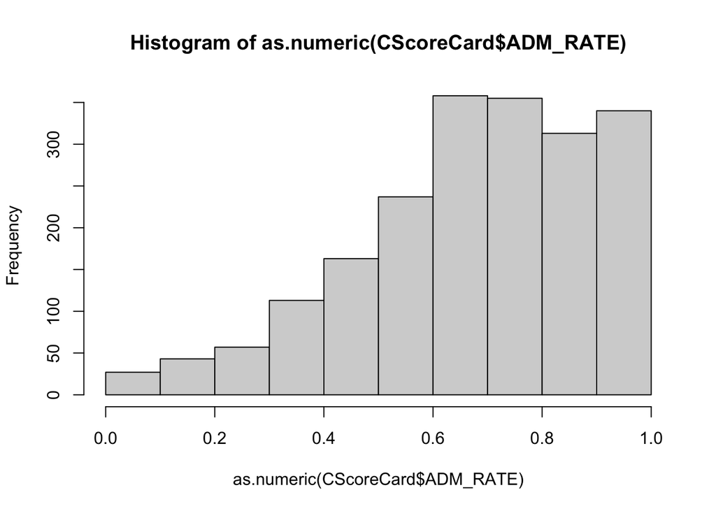

```r
hist(as.numeric(CScoreCard$ADM_RATE))#and here is a histogram of the admit rate frequencies. There seem to be fewer selective institutions in this list.
```

```r
sqrt_sat <- sqrt(sat) #An example transformation of the SAT scores into the square root of the SAT scores
```